# hw2

## Homework 2

##Bodi Yang; byang89@wisc.edu

In this homework, I adopted the “Eclidean method” from the assignment instruction. I have attempted to develop an idea comparing the pattern mononicity of wavelength to study the similarity of the target cB_58 and the spectrum, but not get a satisfying result. I will illustrate the details in this report.

##The Euclidean method I’m using the Euclidean method to complete this study, by following the instruction post by the instructiors. Briefly, the x-coordinates of wavelenth is thought to be irrelevant because of redshift, and we will compare the similiarity of cB_58 and each spectrum based on the Euclidean distances of y-coordinates of flux. The spectrum with smallest Euclidean distance will the ones we are looking for.

To be noticed, y-coordinates will be substracted the mean value of elements in each vector and divided by the standard deviation of elements in each vector. This is to align specta of different brightness and distances.

```r
##Bodi Yang; byang89@wisc.edu
rm(list=ls())
require("FITSio")
data_cB58 <- readFrameFromFITS("cB58_Lyman_break.fit")

##for target cB_58:calculate the mean and standard deviation of y coordinated and then let it substracted by the mean and devided by the standard deviation
logld=data_cB58$LOGLAM
xd=10^logld
yd=data_cB58$FLUX

lengthd=length(yd)
yd_sum=0
yd_mean=0
yd_dev=0

for(i in 1:lengthd){
    yd_sum=yd_sum+yd[i]
}
yd_mean=yd_sum/lengthd

for(i in 1:lengthd){
    yd_dev=(yd_mean-yd[i])^2 + yd_dev
}
yd_dev=sqrt(yd_dev/lengthd)

yd=yd-yd_mean
yd=yd/yd_dev

##read the 100 data files
lf <- list.files(path = "./data/" )
N.files = length(lf)

distances = numeric (N.files)


for (k in 1:N.files){
    ##cat(sep="", "k=", k, ", lf[k]=", lf[k] , "\n")
    df = readFrameFromFITS(paste(sep = "", "data/", lf[k]))
    ##print(head(df))
    loglamw = df$loglam
    x = 10^loglamw
    y = df$flux
    lengthw=length(y)

    ##calculate the mean: y_mean and standard deviation: y_dev
    y_sum=0
    y_mean=0
    y_dev=0

    for(i in 1:lengthw){
        y_sum=y_sum+y[i]
    }
    y_mean=y_sum/lengthw

    for(i in 1:lengthw){
        y_dev=(y_mean-y[i])^2 + y_dev
    }
    y_dev=sqrt(y_dev/lengthw)

    ## each y is sustracted the mean and divided by the standard deviation
    y=y-y_mean
    y=y/y_dev

    ##calculate the Euclidean distances m
    m=0
    if(lengthw>=lengthd){
        for(i in 1:lengthd){
            m=m + (y[i]-yd[i])^2
        }
        for(i in lengthd:lengthw){
            m=m + (y[i]-0)^2
        }
    }
    else{
         for(i in 1:lengthw){
            m=m + (y[i]-yd[i])^2
        }
        for(i in lengthw:lengthd){
            m=m + (yd[di])^2
        }
    }
    m=sqrt(m)
    distances[k]= m
}

##create the data frame of distances, spectrumID; sorted by the distances
##Please note: I did not include "i" in the data frame, because I'm using the Eucledean distance of y-coordinates only, irrelvant of x.
dfs <-data.frame(distances,lf)
names(dfs)<- c("distances", "spectrumID")
dfs = dfs[order(dfs$distances),]

##write.csv(dfs,"hw2.csv", row.names = FALSE)
```

## Plots the three specturm (wavelength-flux)

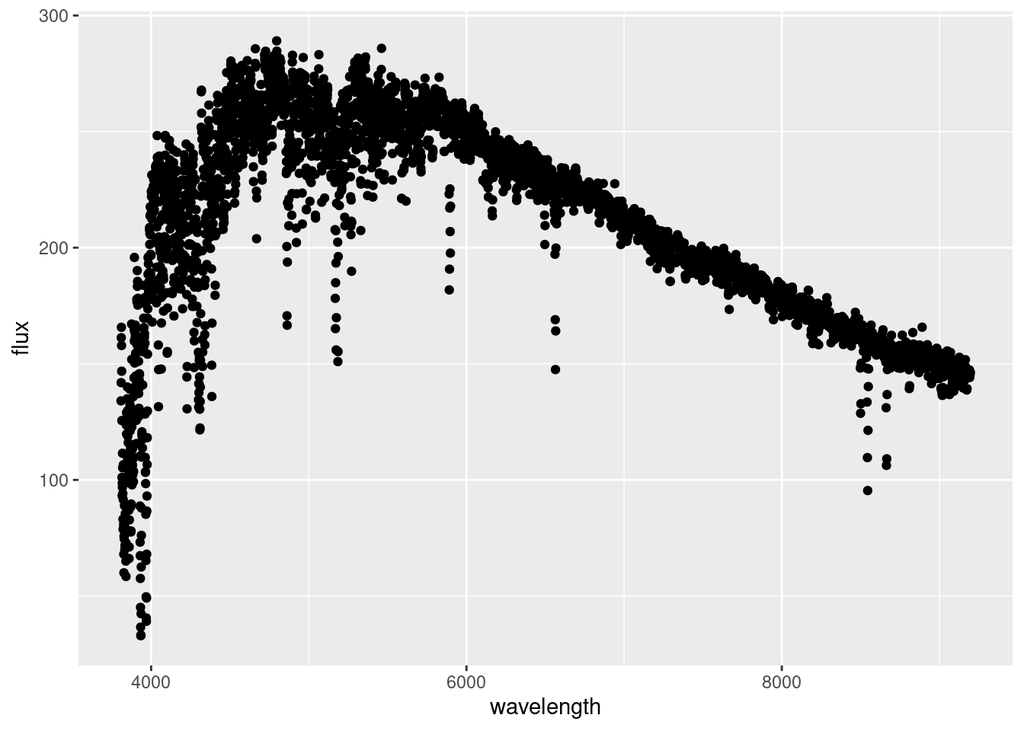

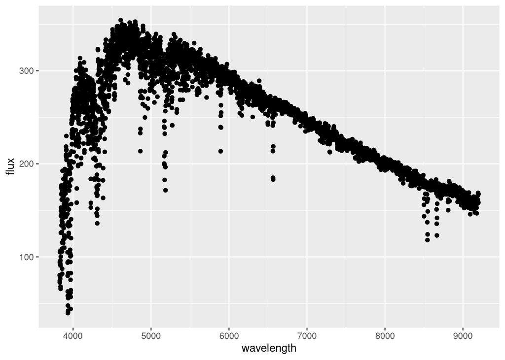

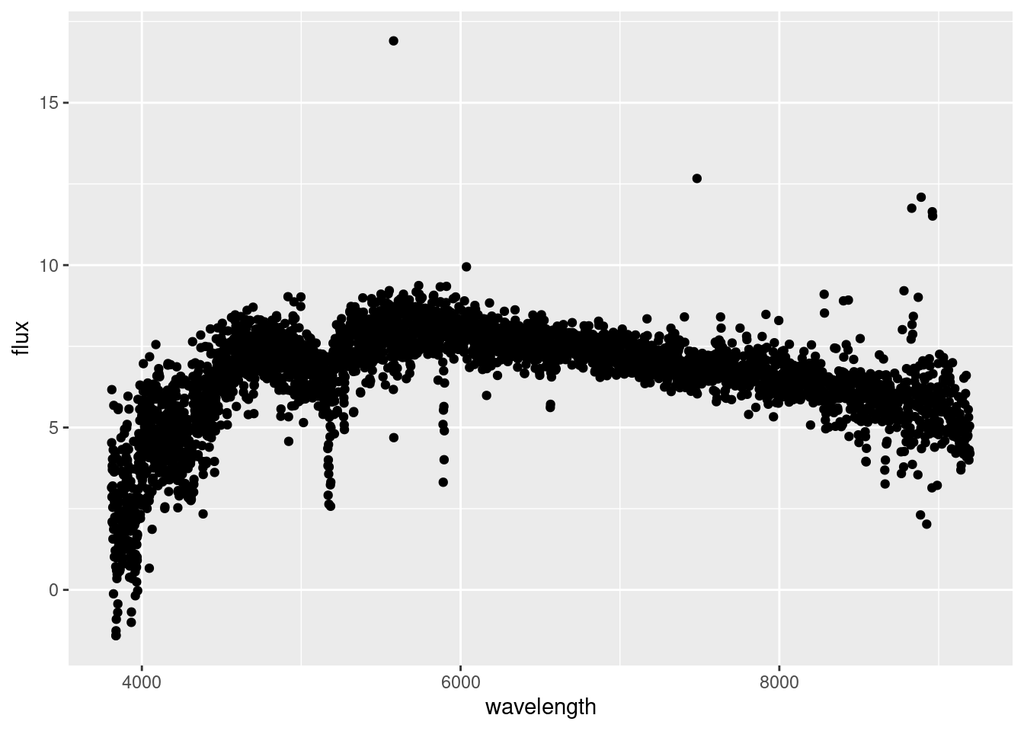

The above would be the wavelength-flux plot of the three spectrum with the smalleste Euclidean distances with thea target cB_58

##failed attempt I have tried another idea: To compare the monotonicity of the data.

Since we only care about the pattern of the data, one way to look at the similarity of the monotonicity between target and the spectrum.

Decide whether each adjacent data is increase or decrease, Ni = X(i+1) - X(i). If Ni=1, then increase, if Ni=-1 then decrease. We can see how many increase and how many decrease period in the target data and spectra data by comparing the sequence Ni.

The similarity between target and the spectrum will be the similarity between the corresponding Ni sequences of them. We will then compare these two sequences by correlation. The smaller, the closer.

(Main process: transfer the multi-dimensional data into one-dimensional sequence; analyze the sequence characteristic to study)

Failed point: I didn’t find a satisfying criteria to compare the two sequences. (The correlation did not lead me to a satisfying result.) I think the reason may be the fact that only focusing on monotonicity neglect the “extent” of the pattern.

**attempted code**

```r
rm(list=ls())
require("FITSio")

##read the data file of cB_5b and sort it by the order of FLUX
data_cB58 <- readFrameFromFITS("cB58_Lyman_break.fit")
dfd = data_cB58 [order(-data_cB58$FLUX),]

##to study the pattern of target cB_58
logld=dfd$LOGLAM
xd=10^logld
yd=dfd$FLUX

lengthd=length(xd)

diff=numeric(lengthd)
diff[1]=0
jdiff=numeric(lengthd)
jdiff[1]=0
##jdiff[i]=1,-1,0 represent the rising or decending pattern
for(i in 2:lengthd){
    diff[i]=xd[i]-xd[i-1]
    if(diff[i]>0){
        jdiff[i]=1
    } else if(diff[i]<0) {
        jdiff[i]=-1
    } else {
        jdiff[i]=0
    }
}

print(jdiff)

lf <- list.files(path = "./data/" )
N.files = length(lf)
distances = numeric (N.files)

for (k in 1:N.files){
    cat(sep="", "k=", k, ", lf[k]=", lf[k] , "\n")
    df = readFrameFromFITS(paste(sep = "", "data/", lf[k]))
    dfw = df[order(-df$flux),]
    loglamw = dfw$loglam
    x = 10^loglamw
    y = dfw$flux
    lengthw=length(x)
    diffw=numeric(lengthw)
    diffw[1]=0
    jdiffw=numeric(lengthw)
    jdiffw[1]=0
    for(i in 2:lengthw){
        diffw[i]=x[i]-x[i-1]
        if(diffw[i]>0){
            jdiffw[i]=1
        } else if(diffw[i]<0) {
            jdiffw[i]=-1
        } else {
            jdiffw[i]=0
        }
    }
    distances[k]= cov(jdiff, jdiffw)
}
```